# Linear Regression

John Hios

16/06/2022

**Library calls**

```r
library(here)
```

**Read cleaned data**

```r
source(here("scripts/clean_gdp_phw_data.R"))
```

```
âˆš ggplot2 3.3.5     âˆš purrr   0.3.4
âˆš tibble  3.1.6     âˆš dplyr   1.0.8
âˆš tidyr   1.2.0     âˆš stringr 1.4.0
âˆš readr   2.1.2     âˆš forcats 0.5.1
```

```r
source(here("scripts/clean_inv_asset_data.R"))
source(here("scripts/clean_gfcf_data.R"))
source(here("scripts/clean_edu_exp_data.R"))
source(here("scripts/clean_gdp_data.R"))
```

**OECD data: Labour Productivity**

Select the G-7 cross-country GDP per hour worked data

```r
gdp_phw_g7 <- gdp_phw %>%
  filter(
    country %in% c("CAN", "FRA", "DEU", "ITA", "JPN", "USA", "GBR"),
    measure == "USD"
  ) %>%
  select(-c(indicator, frequency, measure, subject, flag_codes)) %>%
  rename(gdp_phw_usd = value)
```

**OECD data: Public Spending on Education and GDP**

Select the G-7 cross-country expenditure on education (million USD)

```r
edu_exp_g7 <- edu_exp %>%
  filter(
    country %in% c("CAN", "FRA", "DEU", "ITA", "JPN", "USA", "GBR"),
  ) %>%
  select(-c(indicator, frequency, measure, flag_codes)) %>%
  pivot_wider(names_from = subject, values_from = value) %>%
  rename(
    try_pc_gdp = TRY,
    pry_ntry_pc_gdp = PRY_NTRY,
    pry_try_pc_gdp = PRY_TRY
  ) %>%
  left_join(gdp, by = c("country", "year"))%>%
  mutate(
    try_mln_usd = try_pc_gdp * gdp_mln_usd / 100,
    pry_ntry_mln_usd = pry_ntry_pc_gdp * gdp_mln_usd / 100,
    pry_try_mln_usd = pry_try_pc_gdp * gdp_mln_usd / 100
  ) %>%
  select(-try_pc_gdp, -pry_ntry_pc_gdp, -pry_try_pc_gdp, -gdp_mln_usd) %>%
  arrange(country, year)
```

**OECD Data: Investment by Asset and GFCF**

Select the G-7 cross-country investment by asset (million USD)

```r
inv_asset_g7 <- inv_asset %>%
  filter(
    country %in% c("CAN", "FRA", "DEU", "ITA", "JPN", "USA", "GBR")
    ) %>%
  select(-c(indicator, frequency, measure, flag_codes)) %>%
  pivot_wider(names_from = subject, values_from = value) %>%
  rename(
    ict = OTHMACHINEQT,
    cultasset = CULTASSET,
    infrastuct = OTHBUILDING,
    intelprop = FIXASSET,
    transpeqt = TRANSPEQT,
    dwelling = DWELLING
  ) %>%
  left_join(gfcf, by = c("country", "year")) %>%
  mutate(
    ict_mln_usd = ict * gfcf_mln_usd / 100,
    cultasset_mln_usd = cultasset * gfcf_mln_usd / 100,
    infrastuct_mln_usd = infrastuct * gfcf_mln_usd / 100,
    intelprop_mln_usd = intelprop * gfcf_mln_usd / 100,
    transpeqt_mln_usd = transpeqt * gfcf_mln_usd / 100,
    dwelling_mln_usd = dwelling * gfcf_mln_usd / 100
  ) %>%
  select(-gfcf_mln_usd, -ict, -cultasset, -infrastuct, -intelprop, -transpeqt, -dwelling) %>%
  arrange(country, year)
```

**Data for modelling**

Prepare data for linear regression model

```r
productivity <- gdp_phw_g7 %>%
  left_join(edu_exp_g7, by = c("country", "year")) %>%
  left_join(inv_asset_g7, by = c("country", "year"))

glimpse(productivity)
```

```
Rows: 360
Columns: 12
$ country            <chr> "CAN", "CAN", "CAN", "CAN", "CAN", "CAN", "CAN", "CAN", "CAN", "CAN", "CAN", "CAN", "CAN", "CAN", "CAN", "CAN", "CAN", "CAN~
$ year               <dttm> 1970-01-01, 1971-01-01, 1972-01-01, 1973-01-01, 1974-01-01, 1975-01-01, 1976-01-01, 1977-01-01, 1978-01-01, 1979-01-01, 19~
$ gdp_phw_usd        <dbl> 28.62992, 29.33436, 30.35025, 31.07351, 31.07195, 31.42778, 33.28053, 34.20403, 34.45608, 34.11693, 34.01649, 34.48396, 34.~
$ try_mln_usd        <dbl> NA, NA, NA, NA, NA, NA, NA, NA, NA, NA, NA, NA, NA, NA, NA, NA, NA, NA, NA, NA, NA, NA, NA, NA, NA, NA, NA, NA, NA, NA, 133~
$ pry_ntry_mln_usd   <dbl> NA, NA, NA, NA, NA, NA, NA, NA, NA, NA, NA, NA, NA, NA, NA, NA, NA, NA, NA, NA, NA, NA, NA, NA, NA, NA, NA, NA, NA, NA, 288~
$ pry_try_mln_usd    <dbl> NA, NA, NA, NA, NA, NA, NA, NA, NA, NA, NA, NA, NA, NA, NA, NA, NA, NA, NA, NA, NA, NA, NA, NA, NA, NA, NA, NA, NA, NA, 421~
$ ict_mln_usd        <dbl> NA, NA, NA, NA, NA, NA, 2642.131, 2758.330, 3050.458, 3438.862, 4150.366, 5697.235, 5616.704, 6061.705, 6642.579, 7616.316,~
$ cultasset_mln_usd  <dbl> NA, NA, NA, NA, NA, NA, NA, NA, NA, NA, NA, NA, NA, NA, NA, NA, NA, NA, NA, NA, NA, NA, NA, NA, NA, NA, NA, NA, NA, NA, NA,~
$ infrastuct_mln_usd <dbl> 8870.039, 10039.748, 10300.079, 11278.354, 13374.034, 16161.353, 15926.709, 17483.943, 18867.548, 21855.263, 26077.734, 308~
$ intelprop_mln_usd  <dbl> 1365.360, 1517.127, 1578.875, 1637.687, 1769.458, 2034.349, 2609.275, 2999.763, 3437.905, 3984.102, 4921.618, 5684.890, 614~
$ transpeqt_mln_usd  <dbl> NA, NA, NA, NA, NA, NA, NA, NA, NA, NA, NA, 4158.514, 3149.827, 3769.343, 4845.802, 5469.769, 5658.060, 6602.742, 7291.689,~
$ dwelling_mln_usd   <dbl> 4982.125, 6168.938, 7262.403, 8810.676, 9991.444, 10457.235, 13265.412, 13919.626, 14895.768, 15736.757, 16110.102, 19000.7~
```

Trim UK data

```r
prod_uk_trim <- productivity %>%
  mutate(year = year(year)) %>%
  filter(
    country == "GBR",
    year >= 1995 & year <=2019
  ) %>%
  select(
    gdp_phw_usd,
    ict_mln_usd,
    cultasset_mln_usd,
    infrastuct_mln_usd,
    intelprop_mln_usd,
    transpeqt_mln_usd,
    dwelling_mln_usd
  ) %>%
  mutate(
    ict_bln_usd = ict_mln_usd / 1000,
    cultasset_bln_usd = cultasset_mln_usd / 1000,
    infrastuct_bln_usd = infrastuct_mln_usd / 1000,
    intelprop_bln_usd = intelprop_mln_usd / 1000,
    transpeqt_bln_usd = transpeqt_mln_usd / 1000,
    dwelling_bln_usd = dwelling_mln_usd / 1000
  ) %>%
  select(
    -ict_mln_usd,
    -cultasset_mln_usd,
    -infrastuct_mln_usd,
    -intelprop_mln_usd,
    -transpeqt_mln_usd,
    -dwelling_mln_usd
  )
```

Check for aliases

```r
alias(lm(gdp_phw_usd ~ ., data = prod_uk_trim))
```

```
Model :
gdp_phw_usd ~ ict_bln_usd + cultasset_bln_usd + infrastuct_bln_usd +
    intelprop_bln_usd + transpeqt_bln_usd + dwelling_bln_usd
```

Call libraries for linear regression modelling

```r
library(GGally)
library(ggfortify)
library(modelr)
```

Check data for correlations between variables

[output not shown]

[output cut: 17 more lines]

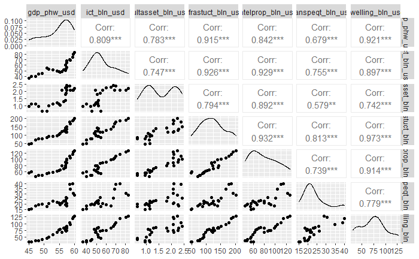

```r
ggpairs(prod_uk_trim)
```

**Automated modelling**

Consider models with up to 6 predictors and pairwise interactions

```r
library(glmulti)
glmulti_fit <- glmulti(
  gdp_phw_usd ~ .,
  data = prod_uk_trim,
  level = 2, # 2 = include pairwise interactions, 1 = main effects only (main effect = no pairwise interactions)
  minsize = 0, # no min size of model
  maxsize = 6, # -1 = no max size of model
  marginality = TRUE, # marginality here means the same as 'strongly hierarchical' interactions, i.e. include pairwise interactions only if both predictors present in the model as main effects.
  method = "g", # the problem is too large for exhaustive search, so search using a genetic algorithm
  crit = bic, # criteria for model selection is BIC value (lower is better)
  plotty = FALSE, # don't plot models as function runs
  report = TRUE, # do produce reports as function runs
  confsetsize = 100, # return best 100 solutions
  fitfunction = lm # fit using the `lm` function
)
```

```
Initialization...
TASK: Genetic algorithm in the candidate set.
Initialization...
Algorithm started...

After 10 generations:
Best model: gdp_phw_usd~1+cultasset_bln_usd+infrastuct_bln_usd+intelprop_bln_usd+dwelling_bln_usd+dwelling_bln_usd:infrastuct_bln_usd
Crit= 56.204684161689
Mean crit= 87.5968860439343
Change in best IC: -9943.79531583831 / Change in mean IC: -9912.40311395607

After 20 generations:
Best model: gdp_phw_usd~1+cultasset_bln_usd+infrastuct_bln_usd+intelprop_bln_usd+dwelling_bln_usd+dwelling_bln_usd:infrastuct_bln_usd
Crit= 56.204684161689
Mean crit= 81.3041530044622
Change in best IC: 0 / Change in mean IC: -6.29273303947208

After 30 generations:
Best model: gdp_phw_usd~1+cultasset_bln_usd+infrastuct_bln_usd+intelprop_bln_usd+dwelling_bln_usd+dwelling_bln_usd:cultasset_bln_usd+dwelling_bln_usd:infrastuct_bln_usd
Crit= 55.6768031771476
Mean crit= 76.8885588508096
Change in best IC: -0.527880984541412 / Change in mean IC: -4.41559415365253

After 40 generations:
Best model: gdp_phw_usd~1+cultasset_bln_usd+infrastuct_bln_usd+intelprop_bln_usd+dwelling_bln_usd+infrastuct_bln_usd:cultasset_bln_usd+dwelling_bln_usd:infrastuct_bln_usd
Crit= 49.3307496150759
Mean crit= 74.1548933429541
Change in best IC: -6.34605356207172 / Change in mean IC: -2.73366550785558

After 50 generations:
Best model: gdp_phw_usd~1+cultasset_bln_usd+infrastuct_bln_usd+intelprop_bln_usd+dwelling_bln_usd+infrastuct_bln_usd:cultasset_bln_usd+dwelling_bln_usd:infrastuct_bln_usd
Crit= 49.3307496150759
Mean crit= 72.466536479519
Change in best IC: 0 / Change in mean IC: -1.68835686343509

After 60 generations:
Best model: gdp_phw_usd~1+cultasset_bln_usd+infrastuct_bln_usd+intelprop_bln_usd+dwelling_bln_usd+infrastuct_bln_usd:cultasset_bln_usd+dwelling_bln_usd:infrastuct_bln_usd
Crit= 49.3307496150759
Mean crit= 71.2478535005786
Change in best IC: 0 / Change in mean IC: -1.21868297894035
```

[output cut: 239 more lines]

[output not shown]

Summary of `glmulti` run results

```r
summary(glmulti_fit)
```

```
$name
[1] "glmulti.analysis"

$method
[1] "g"

$fitting
[1] "lm"

$crit
[1] "bic"

$level
[1] 2

$marginality
[1] TRUE

$confsetsize
[1] 100

$bestic
[1] 49.33075

$icvalues
  [1] 49.33075 55.67680 56.20468 56.55964 57.02945 57.10769 58.16478 58.35922 58.37766 58.58979 58.70080 58.76433 58.82784 59.35794 59.41643 59.73672
 [17] 59.80486 59.91400 60.01813 60.23926 61.21856 61.52268 61.67393 61.69714 62.19404 62.52478 62.58987 62.76328 62.77122 62.83302 62.92747 63.00538
 [33] 63.06098 63.18221 63.26074 63.27490 63.30843 63.55029 63.61374 63.95171 64.49865 64.79650 65.15106 65.26918 65.28582 65.41296 65.44166 65.55156
 [49] 65.62047 65.78757 65.78882 65.91789 66.13587 66.17188 66.17749 66.55359 66.79039 67.14101 67.42008 67.45456 67.51034 67.76719 67.88647 67.96365
 [65] 68.00286 68.02477 68.04365 68.07921 68.31758 68.32821 68.34297 68.37827 68.40555 68.54663 68.74188 68.91153 68.92463 68.94909 68.99457 69.45364
 [81] 69.65318 69.69883 69.96745 70.05665 70.06261 70.15690 70.21565 70.33763 70.34419 70.42668 70.45125 70.48991 70.52488 70.61996 70.68308 70.84462
 [97] 70.86078 70.93826 70.94402 70.96893

$bestmodel
[1] "gdp_phw_usd ~ 1 + cultasset_bln_usd + infrastuct_bln_usd + intelprop_bln_usd + "
[2] "    dwelling_bln_usd + infrastuct_bln_usd:cultasset_bln_usd + "
[3] "    dwelling_bln_usd:infrastuct_bln_usd"

$modelweights
  [1] 7.782936e-01 3.259233e-02 2.503154e-02 2.096089e-02 1.657262e-02 1.593688e-02 9.394170e-03 8.523859e-03 8.445611e-03 7.595719e-03 7.185592e-03
 [12] 6.960922e-03 6.743379e-03 5.173291e-03 5.024199e-03 4.280716e-03 4.137328e-03 3.917593e-03 3.718849e-03 3.329581e-03 2.040505e-03 1.752668e-03
 [23] 1.625013e-03 1.606262e-03 1.252897e-03 1.061929e-03 1.027926e-03 9.425542e-04 9.388220e-04 9.102561e-04 8.682648e-04 8.350945e-04 8.121994e-04
 [34] 7.644286e-04 7.349964e-04 7.298098e-04 7.176766e-04 6.359313e-04 6.160715e-04 5.202855e-04 3.957997e-04 3.410351e-04 2.856313e-04 2.692509e-04
 [45] 2.670202e-04 2.505743e-04 2.470034e-04 2.337974e-04 2.258788e-04 2.077735e-04 2.076437e-04 1.946667e-04 1.745654e-04 1.714503e-04 1.709706e-04
 [56] 1.416614e-04 1.258436e-04 1.056075e-04 9.185328e-05 9.028323e-05 8.780034e-05 7.721845e-05 7.274798e-05 6.999389e-05 6.863507e-05 6.788746e-05
 [67] 6.724961e-05 6.606430e-05 5.864151e-05 5.833063e-05 5.790197e-05 5.688886e-05 5.611802e-05 5.229602e-05 4.743195e-05 4.357429e-05 4.328987e-05
 [78] 4.276373e-05 4.180223e-05 3.322874e-05 3.007342e-05 2.939486e-05 2.570040e-05 2.457935e-05 2.450627e-05 2.337768e-05 2.270103e-05 2.135779e-05
 [89] 2.128791e-05 2.042772e-05 2.017828e-05 1.979199e-05 1.944901e-05 1.854597e-05 1.796986e-05 1.657551e-05 1.644211e-05 1.581727e-05 1.577181e-05
[100] 1.557656e-05

$generations
[1] 480

$elapsed
[1] 0.02157169

$includeobjects
[1] TRUE
```

```r
# here is the best model (lowest BIC) from the glmulti run above
glmulti_fit@objects[1]
```

```
[[1]]

Call:
fitfunc(formula = as.formula(x), data = data)

Coefficients:
                         (Intercept)                     cultasset_bln_usd                    infrastuct_bln_usd                     intelprop_bln_usd
                           25.370831                              2.671541                              0.189267                              0.112780
                    dwelling_bln_usd  cultasset_bln_usd:infrastuct_bln_usd   infrastuct_bln_usd:dwelling_bln_usd
                            0.173074                             -0.036716                             -0.001181
```

```r
# if you want to see the other models
weightable(glmulti_fit)
```

| model | bic | weights |
| --- | --- | --- |
| gdp_phw_usd ~ 1 + cultasset_bln_usd + infrastuct_bln_usd + intelprop_bln_usd + dwelling_bln_usd + infrastuct_bln_usd:cultasset_bln_usd + dwelling_bln_usd:infrastuct_bln_usd | 49.33075 | 7.782936e-01 |
| gdp_phw_usd ~ 1 + cultasset_bln_usd + infrastuct_bln_usd + intelprop_bln_usd + dwelling_bln_usd + dwelling_bln_usd:cultasset_bln_usd + dwelling_bln_usd:infrastuct_bln_usd | 55.67680 | 3.259233e-02 |
| gdp_phw_usd ~ 1 + cultasset_bln_usd + infrastuct_bln_usd + intelprop_bln_usd + dwelling_bln_usd + dwelling_bln_usd:infrastuct_bln_usd | 56.20468 | 2.503154e-02 |
| gdp_phw_usd ~ 1 + cultasset_bln_usd + infrastuct_bln_usd + intelprop_bln_usd + dwelling_bln_usd + intelprop_bln_usd:cultasset_bln_usd + dwelling_bln_usd:infrastuct_bln_usd | 56.55964 | 2.096089e-02 |
| gdp_phw_usd ~ 1 + infrastuct_bln_usd + intelprop_bln_usd + dwelling_bln_usd + dwelling_bln_usd:infrastuct_bln_usd | 57.02945 | 1.657262e-02 |
| gdp_phw_usd ~ 1 + infrastuct_bln_usd + intelprop_bln_usd + transpeqt_bln_usd + dwelling_bln_usd + transpeqt_bln_usd:infrastuct_bln_usd + dwelling_bln_usd:infrastuct_bln_usd | 57.10769 | 1.593688e-02 |
| gdp_phw_usd ~ 1 + cultasset_bln_usd + infrastuct_bln_usd + intelprop_bln_usd + dwelling_bln_usd + dwelling_bln_usd:infrastuct_bln_usd + dwelling_bln_usd:intelprop_bln_usd | 58.16478 | 9.394170e-03 |
| gdp_phw_usd ~ 1 + infrastuct_bln_usd + intelprop_bln_usd + dwelling_bln_usd + intelprop_bln_usd:infrastuct_bln_usd + dwelling_bln_usd:infrastuct_bln_usd + dwelling_bln_usd:intelprop_bln_usd | 58.35922 | 8.523859e-03 |
| gdp_phw_usd ~ 1 + ict_bln_usd + cultasset_bln_usd + infrastuct_bln_usd + dwelling_bln_usd + cultasset_bln_usd:ict_bln_usd + dwelling_bln_usd:infrastuct_bln_usd | 58.37766 | 8.445611e-03 |
| gdp_phw_usd ~ 1 + ict_bln_usd + intelprop_bln_usd + transpeqt_bln_usd + dwelling_bln_usd + transpeqt_bln_usd:ict_bln_usd + dwelling_bln_usd:ict_bln_usd | 58.58979 | 7.595719e-03 |

[output cut: 90 more lines]

**Best model summary (6 regressor terms - predictors and pairwise interactions)**

```r
# View summary of the best model (lowest BIC) from the glmulti run above
mod_auto1 <- lm(gdp_phw_usd ~ 1 + cultasset_bln_usd + infrastuct_bln_usd +
                 intelprop_bln_usd + dwelling_bln_usd +
                 infrastuct_bln_usd:cultasset_bln_usd +
                 dwelling_bln_usd:infrastuct_bln_usd,
                   data = prod_uk_trim)

summary(mod_auto1)
```

```
Call:
lm(formula = gdp_phw_usd ~ 1 + cultasset_bln_usd + infrastuct_bln_usd +
    intelprop_bln_usd + dwelling_bln_usd + infrastuct_bln_usd:cultasset_bln_usd +
    dwelling_bln_usd:infrastuct_bln_usd, data = prod_uk_trim)

Residuals:
     Min       1Q   Median       3Q      Max
-0.59966 -0.29484 -0.05087  0.21457  0.85219

Coefficients:
                                       Estimate Std. Error t value Pr(>|t|)
(Intercept)                          25.3708305  1.7350410  14.623 1.97e-11 ***
cultasset_bln_usd                     2.6715409  1.4146624   1.888 0.075189 .
infrastuct_bln_usd                    0.1892674  0.0208051   9.097 3.75e-08 ***
intelprop_bln_usd                     0.1127803  0.0241826   4.664 0.000193 ***
dwelling_bln_usd                      0.1730740  0.0281927   6.139 8.49e-06 ***
cultasset_bln_usd:infrastuct_bln_usd -0.0367162  0.0122710  -2.992 0.007818 **
infrastuct_bln_usd:dwelling_bln_usd  -0.0011812  0.0001587  -7.441 6.77e-07 ***
---
Signif. codes:  0 ‘***’ 0.001 ‘**’ 0.01 ‘*’ 0.05 ‘.’ 0.1 ‘ ’ 1

Residual standard error: 0.457 on 18 degrees of freedom
Multiple R-squared:  0.9921,    Adjusted R-squared:  0.9895
F-statistic: 378.9 on 6 and 18 DF,  p-value: < 2.2e-16
```

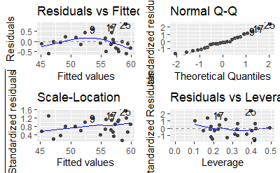

```r
# let's see diagnostic plots
autoplot(mod_auto1)
```

The diagnostic plots don’t look that great, and the `cultasset_bln_usd` coefficient is not statistically significant

Let’s check what the other models calculated by the gmulti algorithm are like

**Summary of model with 4 regressor terms (5th best model from `gmulti` run)**

```r
# View summary of model
mod_auto5 <- lm(gdp_phw_usd ~ 1 + infrastuct_bln_usd + intelprop_bln_usd +
                dwelling_bln_usd + dwelling_bln_usd:infrastuct_bln_usd,
                   data = prod_uk_trim)

summary(mod_auto5)
```

```
Call:
lm(formula = gdp_phw_usd ~ 1 + infrastuct_bln_usd + intelprop_bln_usd +
    dwelling_bln_usd + dwelling_bln_usd:infrastuct_bln_usd, data = prod_uk_trim)

Residuals:
     Min       1Q   Median       3Q      Max
-1.14684 -0.35696 -0.01917  0.25889  1.02190

Coefficients:
                                      Estimate Std. Error t value Pr(>|t|)
(Intercept)                          3.108e+01  9.962e-01  31.197  < 2e-16 ***
infrastuct_bln_usd                   1.261e-01  1.452e-02   8.685 3.20e-08 ***
intelprop_bln_usd                    4.979e-02  1.420e-02   3.506  0.00222 **
dwelling_bln_usd                     2.404e-01  2.126e-02  11.306 3.86e-10 ***
infrastuct_bln_usd:dwelling_bln_usd -1.338e-03  9.823e-05 -13.626 1.40e-11 ***
---
Signif. codes:  0 ‘***’ 0.001 ‘**’ 0.01 ‘*’ 0.05 ‘.’ 0.1 ‘ ’ 1

Residual standard error: 0.5752 on 20 degrees of freedom
Multiple R-squared:  0.9862,    Adjusted R-squared:  0.9834
F-statistic: 356.6 on 4 and 20 DF,  p-value: < 2.2e-16
```

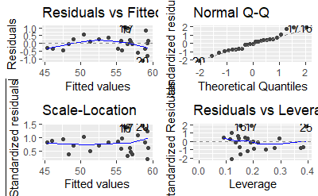

```r
# let's see diagnostic plots
autoplot(mod_auto5)
```

```r
# View summary of model
mod_auto8 <- lm(gdp_phw_usd ~ 1 + ict_bln_usd + cultasset_bln_usd +
                  infrastuct_bln_usd + dwelling_bln_usd +
                  cultasset_bln_usd:ict_bln_usd + dwelling_bln_usd:infrastuct_bln_usd,
                   data = prod_uk_trim)

summary(mod_auto8)
```

```
Call:
lm(formula = gdp_phw_usd ~ 1 + ict_bln_usd + cultasset_bln_usd +
    infrastuct_bln_usd + dwelling_bln_usd + cultasset_bln_usd:ict_bln_usd +
    dwelling_bln_usd:infrastuct_bln_usd, data = prod_uk_trim)

Residuals:
    Min      1Q  Median      3Q     Max
-0.6595 -0.2979 -0.1428  0.1646  1.0839

Coefficients:
                                      Estimate Std. Error t value Pr(>|t|)
(Intercept)                         22.9729453  3.0621277   7.502 6.04e-07 ***
ict_bln_usd                          0.2673784  0.0782419   3.417 0.003071 **
cultasset_bln_usd                    7.7921623  2.3965281   3.251 0.004431 **
infrastuct_bln_usd                   0.0803376  0.0194790   4.124 0.000637 ***
dwelling_bln_usd                     0.2066653  0.0245778   8.409 1.20e-07 ***
ict_bln_usd:cultasset_bln_usd       -0.1263855  0.0421949  -2.995 0.007765 **
infrastuct_bln_usd:dwelling_bln_usd -0.0008769  0.0001570  -5.586 2.66e-05 ***
---
Signif. codes:  0 ‘***’ 0.001 ‘**’ 0.01 ‘*’ 0.05 ‘.’ 0.1 ‘ ’ 1

Residual standard error: 0.5476 on 18 degrees of freedom
Multiple R-squared:  0.9887,    Adjusted R-squared:  0.985
F-statistic:   263 on 6 and 18 DF,  p-value: < 2.2e-16
```

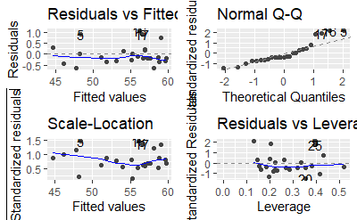

```r
# let's see diagnostic plots
autoplot(mod_auto8)
```

**Interpretation of diagnostic plots**

The diagnostic plots don’t look that great, although all predictor coefficients are statistically significant

The model with the 4 regressor terms (`mod_auto5`) is a good trade-off between accuracy and model parsimony

**Model with 4 regressor terms (5th best model from `gmulti` run)**

View portion of variance explained by each model parameter

```r
library(relaimpo)
calc.relimp(mod_auto5, type = "lmg", rela = TRUE)
```

```
Response variable: gdp_phw_usd
Total response variance: 19.94055
Analysis based on 25 observations

4 Regressors:
infrastuct_bln_usd intelprop_bln_usd dwelling_bln_usd infrastuct_bln_usd:dwelling_bln_usd
Proportion of variance explained by model: 98.62%
Metrics are normalized to sum to 100% (rela=TRUE).

Relative importance metrics:

                                          lmg
infrastuct_bln_usd                  0.3392090
intelprop_bln_usd                   0.1823124
dwelling_bln_usd                    0.3499682
infrastuct_bln_usd:dwelling_bln_usd 0.1285103

Average coefficients for different model sizes:

                                           1X          2Xs          3Xs          4Xs
infrastuct_bln_usd                  0.0956436  0.070723344  0.092790846  0.126098716
intelprop_bln_usd                   0.1522055 -0.008596465 -0.022328081  0.049785353
dwelling_bln_usd                    0.1488264  0.121347416  0.163875966  0.240369357
infrastuct_bln_usd:dwelling_bln_usd       NaN          NaN -0.001210134 -0.001338482
```

**K-fold cross validation**

Create folds for model cross-validation

```r
library(caret)
set.seed(765977) # to reproduce results shown in presentation
# set up options for train function below
cv_10_fold <- trainControl(method = "cv", # cross-validation
                           number = 10, # 10-fold
                           savePredictions = TRUE) # save all predictions
```

Cross validation of model with 4 regressor terms (5th best model from `gmulti` run - `mod_auto5`)

```r
model_4regr_kfold <- train(gdp_phw_usd ~ 1 + infrastuct_bln_usd +
                               intelprop_bln_usd + dwelling_bln_usd +
                               dwelling_bln_usd:infrastuct_bln_usd,
                             data = prod_uk_trim,
                             trControl = cv_10_fold, # use options defined above
                             method = 'lm')
```

```r
model_4regr_kfold$resample
```

| RMSE | Rsquared | MAE | Resample |
| --- | --- | --- | --- |
| 0.3426852 | 1.0000000 | 0.2580109 | Fold01 |
| 0.4804376 | 0.9797244 | 0.3793639 | Fold02 |
| 0.3445736 | 0.9995879 | 0.2979295 | Fold03 |
| 0.4201350 | 0.9936272 | 0.3480255 | Fold04 |
| 0.4167490 | 1.0000000 | 0.3748305 | Fold05 |
| 0.4512873 | 1.0000000 | 0.3323065 | Fold06 |
| 0.7380610 | 0.9572259 | 0.5944022 | Fold07 |
| 0.3527492 | 0.9970314 | 0.3228309 | Fold08 |
| 1.0715279 | 1.0000000 | 1.0621730 | Fold09 |
| 1.2762121 | 1.0000000 | 1.2762040 | Fold10 |

Summary of K-fold runs

```r
tibble(
  model = "Linear model with 4 regressor terms",
  mean_RMSE = mean(model_4regr_kfold$resample$RMSE),
  mean_Rsquared = mean(model_4regr_kfold$resample$Rsquared)
)
```

| model | mean_RMSE | mean_Rsquared |
| --- | --- | --- |
| Linear model with 4 regressor terms | 0.5894418 | 0.9927197 |